# Analyais on external debt and currency crisis in Emerging markets

April.29 2019

## Problem statement and Background

Frequent currency crisis in EMEs: Why so vulnerable?

- a high level of external debt
- external shocks
- politycial instability
- GDP level

## Problem statement and Background

- What factors strengthen or weaken the link between external debt and currency crisis in EMEs?
- How to predict the possibility of a currency crisis happening in the future?
- Policy guidance for central bank policymakers in emerging markets?

Testable hypothesis:

- EMEs with high external debt are more prone to currency crisis risks

## Approach

Variables:

- Dependent variable: possibility of currency crisis (a nominal depreciation of 15% within a year)
- Independent variable: externaldebt/GNI
- Control variable: GDP per capita, level of democracy, US 3-month treasury yield, foreign reserves/total external debt

Data access:

- the World Bank Open Data
- the International Monetary Fund (IMF) Open Data
- the Polity IV Project conducted by the Center for Systemic Peace

## Methods

Data visualizations

- The connection between currency crisis and external debt
- The connection between currency crisis and control variables

Logit model

- Model the probability of a currency crisis happening given all variables
- \[Pr(Currency Crisis = 1) = φ(β0 + β1(External debt to GNI)i,t + β2(Polity2)i,t + β3(US 3m yield)i + β4(lag GDP per capita)i,t + β5(lag reserves to external debt)i,t + yeari + countryt + εi,t)\]

Machine learning

- Predict the classification
- Several models (K nearest neighbours, CART, and Random Forest)

## Result: data visualizations

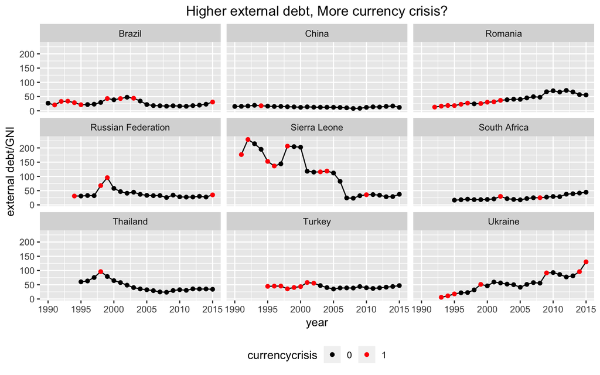

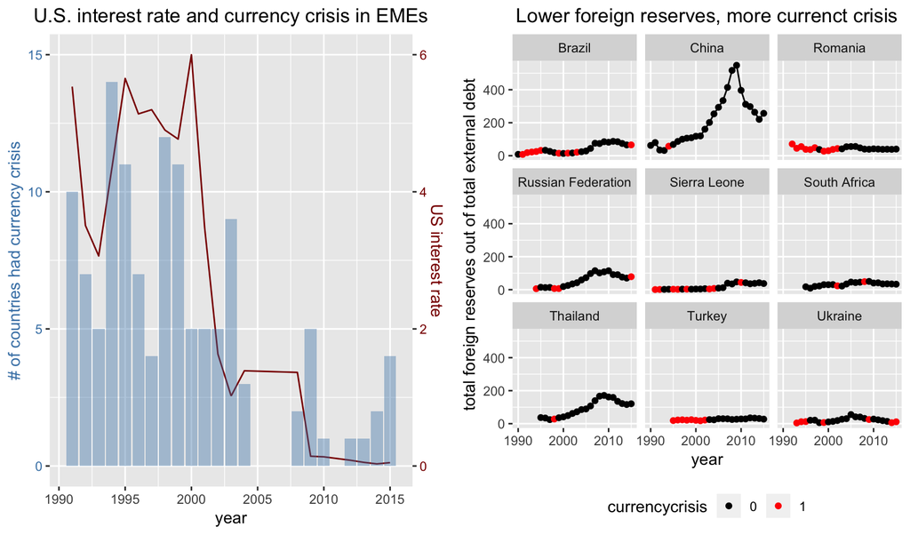

## Result: Logit model

This supports our main hypothesis that countries who have borrowed excessively in foreign currency are more prone to currency crisis risks.

a negative correlation between the ratio of foreign reserves to a country’s total external debt in the previous year and the dependent variable

also a negative correlation between GDP per capita in the previous year and the probability of a currency crisis happening

```
##
## ======================================
##                            Model 1
## --------------------------------------
## (Intercept)                  -3.41 ***
##                              (0.69)
## laggdppercapita              -0.00
##                              (0.00)
## lagtotalreserves             -0.01
##                              (0.01)
## externaldebtgni               0.00 **
##                              (0.00)
## polity2                       0.00
##                              (0.03)
## us3mtreasuryyield             0.17
##                              (0.11)
## --------------------------------------
## AIC                         628.35
## BIC                         667.95
## Log Likelihood             -306.18
## Num. obs.                  1043
## Num. groups: countryx        44
## Num. groups: year            26
## Var: countryx (Intercept)     1.91
## Var: year (Intercept)         1.11
## ======================================
## *** p < 0.001, ** p < 0.01, * p < 0.05
```

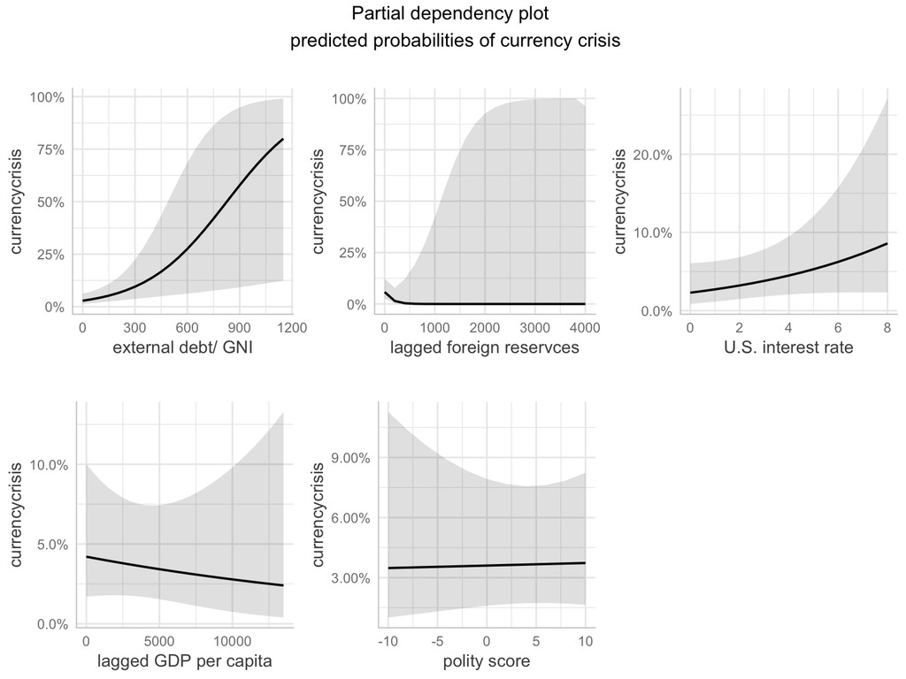

## Result: Machine learning

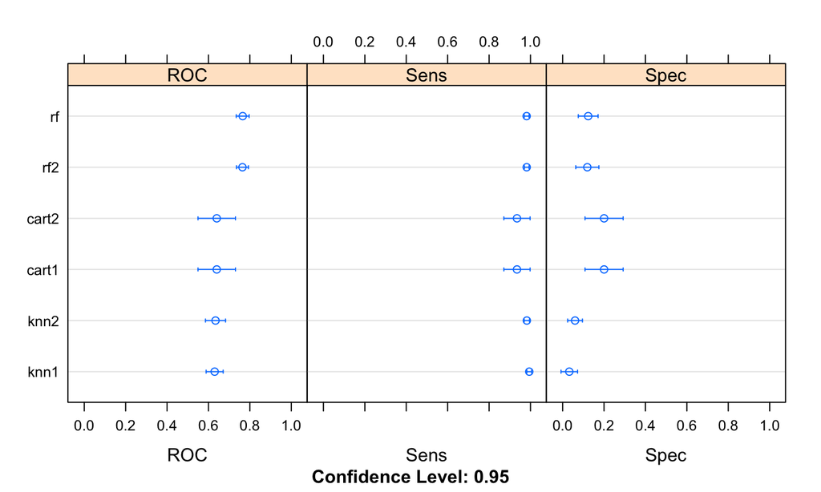

## Predictive performance for mod2_rf

[output not shown]

```
        Sensitivity : 1.0000
        Specificity : 0.0000
     Pos Pred Value : 0.9318
     Neg Pred Value :    NaN
         Prevalence : 0.9318
     Detection Rate : 0.9318
Detection Prevalence : 1.0000
    Balanced Accuracy : 0.5000

    'Positive' Class : no
```

## Most important variables

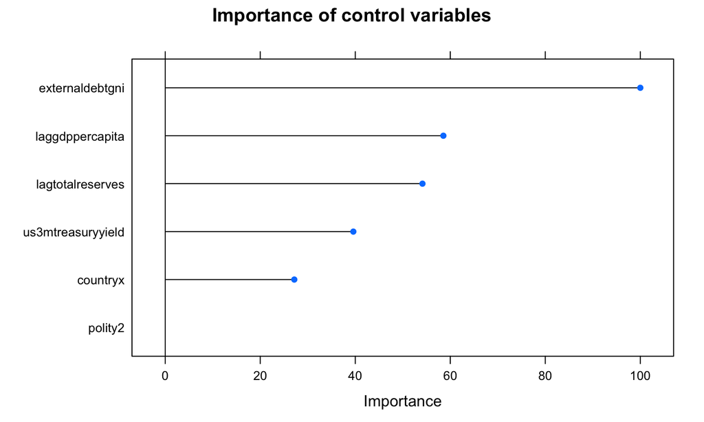

## Lessons learned

- EMEs should control external debt level
- Stock foreign reserves
- Boost GDP
- Monitor U.S. interest rate volatility

## Next steps

- Find a better proxy for political instability
- More variables to include: economic structure & exchange rate regime
- Expand the time rage